# Scaling factor estimation from genomic coverage

```r
setwd("~/mnt/")
library(gvlma)
source("~/HexamerBias/deltaGprediction/binding_model_functions.r")
source('~/HexamerBias/rscripts/hexamer_sequence_functions.r')
```

We want to evaluate if the scaling factor $\varepsilon$ can be correctly estimated using only as a function of the percentage of genomic coverage, without using chi-square minimization for every sample, as suggested by preliminary analysis on a small number of samples. We use a downsampling approach to improve the fit and to rule out sample specific effects.

1. *Estimating epsilon*

No-BS samples where downsampled to variable percentage of reads and primer-template tables were computed for all downsampled bam files and processed to RDS tables with `pt_tab_to_rdata.r`. I estimate epsilon for each RDS table with the `epsilon_downsampling.r` script (on cluster, faster).

Loading saved results

| smp | eps |
| --- | --- |
| human_15 | 700.3561 |
| human_25 | 1100.5603 |
| human_20 | 900.4582 |
| human_30 | 1300.6623 |
| cele_40 | 56028.1058 |
| cele_25 | 35017.5723 |
| cele_30 | 42021.0847 |
| cele_60 | 83741.9846 |
| cele_15 | 21310.6990 |
| cele_50 | 69835.0235 |

[output cut: 41 more lines]

2. *Measuring genomic coverage*

For each bam file we measure percentage of uncovered genome with `bedtools genomecov`.

Loading saved results

| smp | genomecov |
| --- | --- |
| human_15 | 0.046686 |
| human_20 | 0.061208 |
| human_25 | 0.075298 |
| human_30 | 0.088978 |
| human_35 | 0.102273 |
| human_40 | 0.115179 |
| human_45 | 0.127703 |
| human_50 | 0.139917 |
| human_55 | 0.151796 |
| human_60 | 0.163340 |

[output cut: 24 more lines]

The value of epsilon scales nicely with genomic coverage, following a power law.

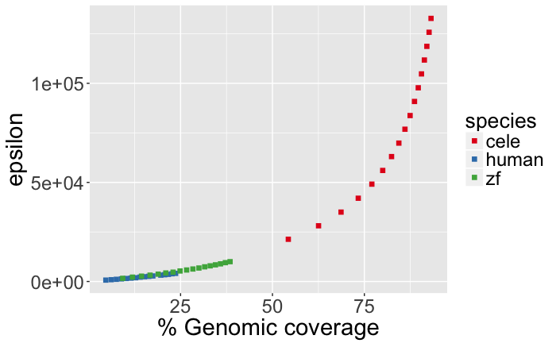

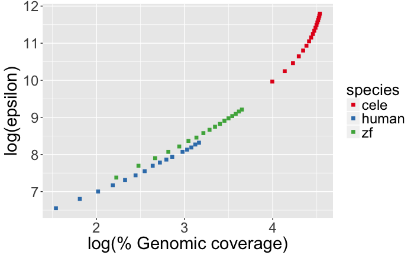

The distribution is quite skewed at the higher end of the genomic coveerage spectrum (close to 100% coverage), but for the purpose of predicting coverage in BS-seq (where the coverage is usually ~ 10%) we can fit only with $x<0.5$.

```r
summary(model.epsilon)
```

```
Call:
lm(formula = log.eps ~ log(genomecov), data = .)

Residuals:
     Min       1Q   Median       3Q      Max
-0.16457 -0.10787  0.04537  0.08013  0.18736

Coefficients:
               Estimate Std. Error t value Pr(>|t|)
(Intercept)    10.33367    0.06237  165.69   <2e-16 ***
log(genomecov)  1.29538    0.03460   37.44   <2e-16 ***
---
Signif. codes:  0 ‘***’ 0.001 ‘**’ 0.01 ‘*’ 0.05 ‘.’ 0.1 ‘ ’ 1

Residual standard error: 0.1057 on 31 degrees of freedom
Multiple R-squared:  0.9784,    Adjusted R-squared:  0.9777
F-statistic:  1402 on 1 and 31 DF,  p-value: < 2.2e-16
```

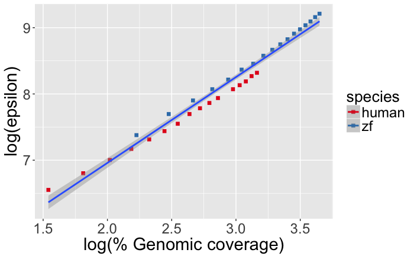

#### Adding more samples

| smp | genomecov |
| --- | --- |
| CG-BS-pbat-bulk-1xPreamp-cElegans-whole-handMixNew_lmerged_R1_trimmed_bismark_bt2.deduplicated.srt | 0.588065 |
| CG-BS-pbat-bulk-1xPreamp-cElegans-whole-handMixOld_lmerged_R1_trimmed_bismark_bt2.deduplicated.srt | 0.432785 |
| CG-BS-pbat-bulk-1xPreamp-cElegans-whole-moreG_lmerged_R1_trimmed_bismark_bt2.deduplicated.srt | 0.395253 |
| CG-BS-pbat-bulk-1xPreamp-cElegans-whole-moreT_lmerged_R1_trimmed_bismark_bt2.deduplicated.srt | 0.482853 |
| CG-BS-pbat-bulk-1xPreamp-dRerio-whole-handMixNew_lmerged_R1_trimmed_bismark_bt2.deduplicated.srt | 0.073663 |
| CG-BS-pbat-bulk-1xPreamp-dRerio-whole-handMixOld_lmerged_R1_trimmed_bismark_bt2.deduplicated.srt | 0.069966 |
| CG-BS-pbat-bulk-1xPreamp-dRerio-whole-moreG_lmerged_R1_trimmed_bismark_bt2.deduplicated.srt | 0.064210 |
| CG-BS-pbat-bulk-1xPreamp-dRerio-whole-moreT_lmerged_R1_trimmed_bismark_bt2.deduplicated.srt | 0.061376 |
| CG-BS-pbat-bulk-1xPreamp-human-APKS-handMixNew_lmerged_R1_trimmed_bismark_bt2.deduplicated.srt | 0.041549 |
| CG-BS-pbat-bulk-1xPreamp-human-APKS-handMixOld_lmerged_R1_trimmed_bismark_bt2.deduplicated.srt | 0.043977 |

[output cut: 22 more lines]

Including BS-seq samples processed in the same way, estimating epsilon only on hexamers not containing cytosines (not affected by bisulfite conversion), for both WGS and BS-seq samples.

```r
eps.bs.downsample <- read.csv("~/mnt/edann/VAN2423_onePreamp/bootstrap/bootstrap_epsilon_BS.txt", header=F, col.names = c('smp', 'eps'))
eps.bs.downsample <- eps.bs.downsample %>%
  mutate(smp = gsub(smp, pattern = '_all', replacement = ''))
eps.bs.downsample
```

```r
gencov.bs.downsample <- read.table("~/mnt/edann/VAN2423_onePreamp/bootstrap/bootstrap_genomecov_wBS.tsv", sep='\t', header=F, col.names = c('smp', 'genomecov'))

gencov.bs.downsample <-
  gencov.bs.downsample %>%
  mutate(genomecov=1-genomecov) %>%
  mutate(smp=gsub(smp, pattern = 'Total|APKS|ish', replacement = '')) %>%
  mutate(smp=paste0(tolower(gsub(pattern = '-.+BS', replacement = '', smp)), ifelse(grepl('with', smp), '_BS', '')))

gencov.bs.downsample
```

```r
eps.bs.df <- inner_join(gencov.bs.downsample, eps.bs.downsample, by='smp') %>%
  mutate(species=gsub(smp, pattern = '_.+', replacement = ''))

p1 <- eps.bs.df %>%
  ggplot(., aes((genomecov)*100, (eps), color=species)) +
  geom_point(shape=15, size=2) +
  scale_color_brewer(palette='Set1') +
  xlab("% Genomic coverage") + ylab("epsilon") +
    theme(axis.text = element_text(size=18),
    axis.title = element_text(size=22),
    legend.title = element_text(size=20),
    legend.text = element_text(size=18)) +
  # geom_smooth(method='lm', aes(color=NULL))
  NULL

p2 <- eps.bs.df %>%
  ggplot(., aes(log(genomecov*100), log(eps), color=species)) +
  geom_point(shape=15, size=2) +
  scale_color_brewer(palette='Set1') +
  xlab("log(% Genomic coverage)") + ylab("log(epsilon)") +
    theme(axis.text = element_text(size=18),
    axis.title = element_text(size=22),
    legend.title = element_text(size=20),
    legend.text = element_text(size=18)) +
  # geom_smooth(method='lm', aes(color=NULL))
  NULL

p1; p2
```

[output not shown]

Try again without downsampling.

```r
cele.bs.all.df <- readRDS("~/mnt/edann/VAN2423_onePreamp/cov_prediction/cele_BS_all.RDS")
human.bs.all.df <- readRDS("~/mnt/edann/VAN2423_onePreamp/cov_prediction/human_BS_all.RDS")
zf.bs.all.df <- readRDS("~/mnt/edann/VAN2423_onePreamp/cov_prediction/zf_BS_all.RDS")
```

```r
celebs.noC <- cele.bs.all.df %>%
  filter(template==primer) %>%
  filter(!grepl(template, pattern = "C"))

eps.celebs <- epsilon.minimize.chisq(celebs.noC, max=1000)


zfbs.noC <- zf.bs.all.df %>%
  filter(template==primer) %>%
  filter(!grepl(template, pattern = "C"))

eps.zfbs <- epsilon.minimize.chisq(zfbs.noC, max=1000)


zfbs.noC <- zf.bs.all.df %>%
  filter(template==primer) %>%
  filter(!grepl(template, pattern = "C"))

eps.zfbs <- epsilon.minimize.chisq(zfbs.noC, max=1000)

humanbs.noC <- human.bs.all.df %>%
  filter(template==primer) %>%
  filter(!grepl(template, pattern = "C"))

eps.humanbs <- epsilon.minimize.chisq(humanbs.noC, max=1000)
```

```r
eps.bs.downsample <- read.csv("~/mnt/edann/VAN2423_onePreamp/cov_prediction/bootstrap_epsilon.txt", header=F, col.names = c('smp', 'eps'))
eps.bs.downsample <- eps.bs.downsample %>%
  mutate(smp = gsub(smp, pattern = '_all', replacement = '')) %>%
  filter(smp!='zf_95_BS')

eps.bs.downsample
```

```r
gencov.bs <- gencov.bs.downsample %>%
  filter(grepl("BS", smp)) %>%
  mutate(perc=as.numeric(gsub(gsub(smp, pattern = '_BS', replacement = ''), pattern='.*_', replacement = ''))) %>%
  filter(perc==95)

eps.nobs <- data.frame(smp=c('cele', 'human', 'zf', 'cele_BS', 'human_BS', 'zf_BS'), eps=c(chi.cele.onlyC, chi.human.onlyC, chi.zf.onlyC))
eps.all.df <- bind_rows(eps.nobs, eps.bs.downsample)

gg <- genome.cov %>%
  rename(smp=species, genomecov=cov) %>%
  bind_rows(., gencov.bs) %>%
  mutate(smp=gsub(smp, pattern='_95', replacement = ''))

gg %>%
  inner_join(., eps.all.df) %>%
  # mutate(type=ifelse(grepl("BS", smp), "BS", 'noBS')) %>%
  ggplot(., aes(log(genomecov), log(eps))) +
  geom_point() +
  geom_text_repel(aes(label=smp))
```

[output not shown]